```python
# This Python 3 environment comes with many helpful analytics libraries installed
# It is defined by the kaggle/python docker image: https://github.com/kaggle/docker-python
# For example, here's several helpful packages to load in

import numpy as np # linear algebra
import pandas as pd # data processing, CSV file I/O (e.g. pd.read_csv)

# Input data files are available in the "../input/" directory.
# For example, running this (by clicking run or pressing Shift+Enter) will list all files under the input directory

import os
for dirname, _, filenames in os.walk('/kaggle/input'):
    for filename in filenames:
        print(os.path.join(dirname, filename))

# Any results you write to the current directory are saved as output.
```

```
/kaggle/input/foreign-exchange-rates-per-dollar-20002019/Foreign_Exchange_Rates.xlsx
/kaggle/input/foreign-exchange-rates-per-dollar-20002019/Foreign_Exchange_Rates.csv
```

# 1. Introduction

# 2. EDA

```python
df=pd.read_csv("/kaggle/input/foreign-exchange-rates-per-dollar-20002019/Foreign_Exchange_Rates.csv")
```

```python
df.head()
```

|  | Unnamed: 0 | Time Serie | AUSTRALIA - AUSTRALIAN DOLLAR/US$ | EURO AREA - EURO/US$ | NEW ZEALAND - NEW ZELAND DOLLAR/US$ | UNITED KINGDOM - UNITED KINGDOM POUND/US$ | BRAZIL - REAL/US$ | CANADA - CANADIAN DOLLAR/US$ | CHINA - YUAN/US$ | HONG KONG - HONG KONG DOLLAR/US$ | ... | SINGAPORE - SINGAPORE DOLLAR/US$ | DENMARK - DANISH KRONE/US$ | JAPAN - YEN/US$ | MALAYSIA - RINGGIT/US$ | NORWAY - NORWEGIAN KRONE/US$ | SWEDEN - KRONA/US$ | SRI LANKA - SRI LANKAN RUPEE/US$ | SWITZERLAND - FRANC/US$ | TAIWAN - NEW TAIWAN DOLLAR/US$ | THAILAND - BAHT/US$ |
| --- | --- | --- | --- | --- | --- | --- | --- | --- | --- | --- | --- | --- | --- | --- | --- | --- | --- | --- | --- | --- | --- |
| 0 | 0 | 2000-01-03 | 1.5172 | 0.9847 | 1.9033 | 0.6146 | 1.805 | 1.4465 | 8.2798 | 7.7765 | ... | 1.6563 | 7.329 | 101.7 | 3.8 | 7.964 | 8.443 | 72.3 | 1.5808 | 31.38 | 36.97 |
| 1 | 1 | 2000-01-04 | 1.5239 | 0.97 | 1.9238 | 0.6109 | 1.8405 | 1.4518 | 8.2799 | 7.7775 | ... | 1.6535 | 7.218 | 103.09 | 3.8 | 7.934 | 8.36 | 72.65 | 1.5565 | 30.6 | 37.13 |
| 2 | 2 | 2000-01-05 | 1.5267 | 0.9676 | 1.9339 | 0.6092 | 1.856 | 1.4518 | 8.2798 | 7.778 | ... | 1.656 | 7.208 | 103.77 | 3.8 | 7.935 | 8.353 | 72.95 | 1.5526 | 30.8 | 37.1 |
| 3 | 3 | 2000-01-06 | 1.5291 | 0.9686 | 1.9436 | 0.607 | 1.84 | 1.4571 | 8.2797 | 7.7785 | ... | 1.6655 | 7.2125 | 105.19 | 3.8 | 7.94 | 8.3675 | 72.95 | 1.554 | 31.75 | 37.62 |
| 4 | 4 | 2000-01-07 | 1.5272 | 0.9714 | 1.938 | 0.6104 | 1.831 | 1.4505 | 8.2794 | 7.7783 | ... | 1.6625 | 7.2285 | 105.17 | 3.8 | 7.966 | 8.415 | 73.15 | 1.5623 | 30.85 | 37.3 |

5 rows × 24 columns

Looks like the "unnamed:0" is the same as our index column, so let's drop it first

```python
df=df.drop('Unnamed: 0',axis=1)
```

Let's look at the statistics of dataframe.

```python
df.describe(include='all')
```

|  | Time Serie | AUSTRALIA - AUSTRALIAN DOLLAR/US$ | EURO AREA - EURO/US$ | NEW ZEALAND - NEW ZELAND DOLLAR/US$ | UNITED KINGDOM - UNITED KINGDOM POUND/US$ | BRAZIL - REAL/US$ | CANADA - CANADIAN DOLLAR/US$ | CHINA - YUAN/US$ | HONG KONG - HONG KONG DOLLAR/US$ | INDIA - INDIAN RUPEE/US$ | ... | SINGAPORE - SINGAPORE DOLLAR/US$ | DENMARK - DANISH KRONE/US$ | JAPAN - YEN/US$ | MALAYSIA - RINGGIT/US$ | NORWAY - NORWEGIAN KRONE/US$ | SWEDEN - KRONA/US$ | SRI LANKA - SRI LANKAN RUPEE/US$ | SWITZERLAND - FRANC/US$ | TAIWAN - NEW TAIWAN DOLLAR/US$ | THAILAND - BAHT/US$ |
| --- | --- | --- | --- | --- | --- | --- | --- | --- | --- | --- | --- | --- | --- | --- | --- | --- | --- | --- | --- | --- | --- |
| count | 5217 | 5217 | 5217 | 5217 | 5217 | 5217 | 5217 | 5217 | 5217 | 5217 | ... | 5217 | 5217 | 5217 | 5217 | 5217 | 5217 | 5217 | 5217 | 5217 | 5217 |
| unique | 5217 | 2959 | 2704 | 2681 | 2303 | 3880 | 3147 | 2711 | 893 | 1998 | ... | 2927 | 4462 | 2848 | 1788 | 4511 | 4574 | 1781 | 3190 | 714 | 1380 |
| top | 2005-11-02 | ND | ND | ND | ND | ND | ND | 8.2765 | ND | ND | ... | ND | ND | ND | 3.8 | ND | ND | ND | ND | ND | ND |
| freq | 1 | 198 | 198 | 198 | 198 | 198 | 198 | 208 | 198 | 199 | ... | 198 | 198 | 198 | 1376 | 198 | 198 | 198 | 198 | 201 | 198 |

4 rows × 23 columns

One thing I noticed was that this result which is supposed to cotain the mean, std and min values for all currencies do not actually have anything. This is weird as we clearly have numbers in our original dataframe. It could be because these numbers are not float values. Let's check the datatype with an 'info' method.

```python
df.info(verbose=True)
```

```
<class 'pandas.core.frame.DataFrame'>
RangeIndex: 5217 entries, 0 to 5216
Data columns (total 23 columns):
Time Serie                                   5217 non-null object
AUSTRALIA - AUSTRALIAN DOLLAR/US$            5217 non-null object
EURO AREA - EURO/US$                         5217 non-null object
NEW ZEALAND - NEW ZELAND DOLLAR/US$          5217 non-null object
UNITED KINGDOM - UNITED KINGDOM POUND/US$    5217 non-null object
BRAZIL - REAL/US$                            5217 non-null object
CANADA - CANADIAN DOLLAR/US$                 5217 non-null object
CHINA - YUAN/US$                             5217 non-null object
HONG KONG - HONG KONG DOLLAR/US$             5217 non-null object
INDIA - INDIAN RUPEE/US$                     5217 non-null object
KOREA - WON/US$                              5217 non-null object
MEXICO - MEXICAN PESO/US$                    5217 non-null object
SOUTH AFRICA - RAND/US$                      5217 non-null object
SINGAPORE - SINGAPORE DOLLAR/US$             5217 non-null object
DENMARK - DANISH KRONE/US$                   5217 non-null object
JAPAN - YEN/US$                              5217 non-null object
MALAYSIA - RINGGIT/US$                       5217 non-null object
NORWAY - NORWEGIAN KRONE/US$                 5217 non-null object
SWEDEN - KRONA/US$                           5217 non-null object
SRI LANKA - SRI LANKAN RUPEE/US$             5217 non-null object
SWITZERLAND - FRANC/US$                      5217 non-null object
TAIWAN - NEW TAIWAN DOLLAR/US$               5217 non-null object
THAILAND - BAHT/US$                          5217 non-null object
dtypes: object(23)
memory usage: 937.6+ KB
```

Ah, we can see that all of our values in the dataframe are not floats but strings. Let's turn the number columns into numerical feature columns.

```python
col_list=list(df)
```

```python
#excluding the "0" the column, date column, as it will be converted to date-time object.
df[col_list[1:]] = df[col_list[1:]].apply(pd.to_numeric, errors='coerce')
```

Then let's take care of Time series column data by converting it to date_time.

```python
df['Time Serie']=pd.to_datetime(df['Time Serie'])
```

Checking the data type one more time.

```python
df.info(verbose=True)
```

```
<class 'pandas.core.frame.DataFrame'>
RangeIndex: 5217 entries, 0 to 5216
Data columns (total 23 columns):
Time Serie                                   5217 non-null datetime64[ns]
AUSTRALIA - AUSTRALIAN DOLLAR/US$            5019 non-null float64
EURO AREA - EURO/US$                         5019 non-null float64
NEW ZEALAND - NEW ZELAND DOLLAR/US$          5019 non-null float64
UNITED KINGDOM - UNITED KINGDOM POUND/US$    5019 non-null float64
BRAZIL - REAL/US$                            5019 non-null float64
CANADA - CANADIAN DOLLAR/US$                 5019 non-null float64
CHINA - YUAN/US$                             5020 non-null float64
HONG KONG - HONG KONG DOLLAR/US$             5019 non-null float64
INDIA - INDIAN RUPEE/US$                     5018 non-null float64
KOREA - WON/US$                              5019 non-null float64
MEXICO - MEXICAN PESO/US$                    5019 non-null float64
SOUTH AFRICA - RAND/US$                      5019 non-null float64
SINGAPORE - SINGAPORE DOLLAR/US$             5019 non-null float64
DENMARK - DANISH KRONE/US$                   5019 non-null float64
JAPAN - YEN/US$                              5019 non-null float64
MALAYSIA - RINGGIT/US$                       5019 non-null float64
NORWAY - NORWEGIAN KRONE/US$                 5019 non-null float64
SWEDEN - KRONA/US$                           5019 non-null float64
SRI LANKA - SRI LANKAN RUPEE/US$             5019 non-null float64
SWITZERLAND - FRANC/US$                      5019 non-null float64
TAIWAN - NEW TAIWAN DOLLAR/US$               5016 non-null float64
THAILAND - BAHT/US$                          5019 non-null float64
dtypes: datetime64[ns](1), float64(22)
memory usage: 937.6 KB
```

Now it looks correct :) Alright onto the real EDA!

Let's change the structure of the dataframe such that we list all the currency types in one column. The same goes for the "value" attribute.

```python
df_melted=df.melt(id_vars=["Time Serie"],
        var_name="Currency type",
        value_name="Value")
```

```python
df_melted.head()
```

|  | Time Serie | Currency type | Value |
| --- | --- | --- | --- |
| 0 | 2000-01-03 | AUSTRALIA - AUSTRALIAN DOLLAR/US$ | 1.5172 |
| 1 | 2000-01-04 | AUSTRALIA - AUSTRALIAN DOLLAR/US$ | 1.5239 |
| 2 | 2000-01-05 | AUSTRALIA - AUSTRALIAN DOLLAR/US$ | 1.5267 |
| 3 | 2000-01-06 | AUSTRALIA - AUSTRALIAN DOLLAR/US$ | 1.5291 |
| 4 | 2000-01-07 | AUSTRALIA - AUSTRALIAN DOLLAR/US$ | 1.5272 |

Looking good. Let's plot the dataset then.

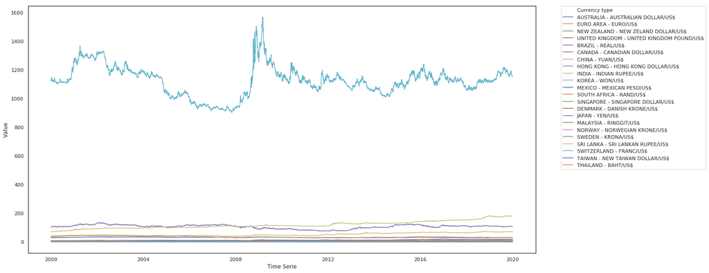

```python
import seaborn as sns; sns.set()
import matplotlib.pyplot as plt

sns.set_style("white")
plt.figure(figsize=(20,10))
sns.lineplot(x="Time Serie", y="Value", hue="Currency type",palette='deep',data=df_melted)
plt.legend(bbox_to_anchor=(1.05, 1), loc=2, borderaxespad=0.)
```

It seems like Korea-Won data's high value pushed other data to the bottom, making it hard to analyze.

Let's separate Korea-Won data from the orignal dataframe to distinguish it from the rest of the dataset.

```python
df_melted_kor=df_melted.loc[df_melted['Currency type'] == "KOREA - WON/US$"]
df_melted_nonkor=df_melted.loc[df_melted['Currency type'] != "KOREA - WON/US$"]
```

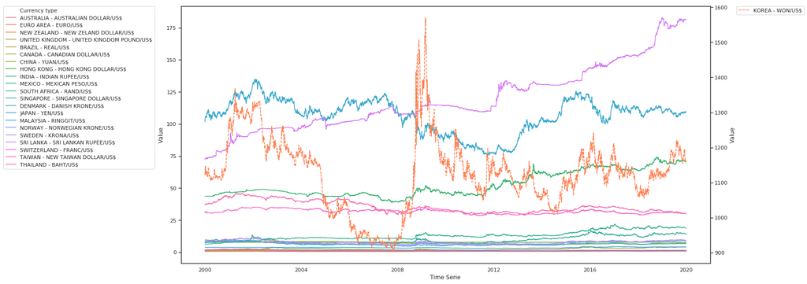

```python
import seaborn as sns; sns.set()
import matplotlib.pyplot as plt

sns.set_style("white")
fig, ax1 = plt.subplots(figsize=(20,10))
ax2 = ax1.twinx()

g=sns.lineplot(x="Time Serie", y="Value", hue="Currency type",ax=ax1,data=df_melted_nonkor)
g.legend(bbox_to_anchor=(-0.05, 1), loc=0, borderaxespad=0.)

#Using the dashes for korea data to stand out
g1=sns.lineplot(x="Time Serie", y="Value", color="coral",label="KOREA - WON/US$",ax=ax2,data=df_melted_kor)
g1.lines[0].set_linestyle("--")
g1.legend(bbox_to_anchor=(1.05, 1), loc=2, borderaxespad=0.)
```

Based on this plot, it seems like Korea Won had experiened a large spike during year 2008 when there was a global economic crsis.

# 3. Time series analysis

Facebook released time series forecasting tool called Prophet in 2017. This was designed to analyze time-series on different time scales such as yearly, weekly and daily. Let's use this on our Korea data for time series analysis.

Prophet requires you to have two columns, "ds" and "y" with the dates and values respectively.

```python
kor_data = df_melted_kor.drop("Currency type",axis=1).rename(columns={'Time Serie': 'ds', 'Value': 'y'})
```

```python
kor_data
```

|  | ds | y |
| --- | --- | --- |
| 46953 | 2000-01-03 | 1128.00 |
| 46954 | 2000-01-04 | 1122.50 |
| 46955 | 2000-01-05 | 1135.00 |
| 46956 | 2000-01-06 | 1146.50 |
| 46957 | 2000-01-07 | 1138.00 |
| ... | ... | ... |
| 52165 | 2019-12-25 | NaN |
| 52166 | 2019-12-26 | 1161.18 |
| 52167 | 2019-12-27 | 1160.87 |
| 52168 | 2019-12-30 | 1155.75 |
| 52169 | 2019-12-31 | 1155.46 |

5217 rows × 2 columns

The data was split into 80% of training data and 20% of test data.

```python
#splitting 80% training and 20% testing

train_kor_data, test_kor_data = np.split(kor_data, [int(.8*len(df))])
```

Let's fit the train data set and create future dataframe for 4 years (4*365)

```python
from fbprophet import Prophet

prophet_basic=Prophet()
prophet_basic.fit(train_kor_data)
train_kor_future= prophet_basic.make_future_dataframe(periods=4*365)
```

Alright. Now we can call the predict method. This will assign each row in our 'future' dataframe a predicted value, which it names yhat. Additionally, it will show lower/upper bounds of uncertainty, called yhat_lower and yhat_upper. (ref:https://www.interviewqs.com/ddi_code_snippets/prophet_intro)

I will also plot the predicted train dataset.

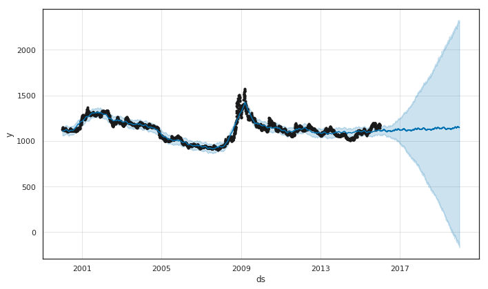

```python
train_kor_forecast=prophet_basic.predict(train_kor_future)
fig1 =prophet_basic.plot(train_kor_forecast)
```

Let's also display the changepoints (points where real time series frequently have abrupt changes in their trajectories) to see if the model correctly recognized them.

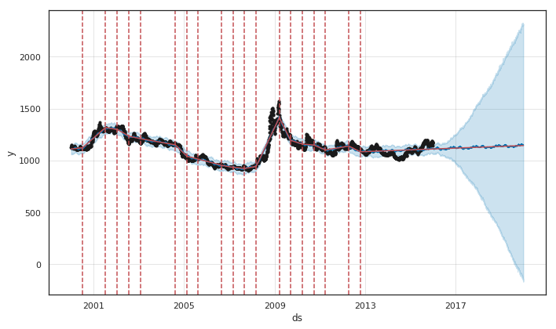

```python
from fbprophet.plot import add_changepoints_to_plot
fig = prophet_basic.plot(train_kor_forecast)
a = add_changepoints_to_plot(fig.gca(), prophet_basic, train_kor_forecast)
```

It seems the model correctly recognized the abrupt change points. Let's look at the predicted train dataframe.

```python
train_kor_forecast.head()
```

|  | ds | trend | yhat_lower | yhat_upper | trend_lower | trend_upper | additive_terms | additive_terms_lower | additive_terms_upper | weekly | weekly_lower | weekly_upper | yearly | yearly_lower | yearly_upper | multiplicative_terms | multiplicative_terms_lower | multiplicative_terms_upper | yhat |
| --- | --- | --- | --- | --- | --- | --- | --- | --- | --- | --- | --- | --- | --- | --- | --- | --- | --- | --- | --- |
| 0 | 2000-01-03 | 1110.630812 | 1065.046765 | 1155.055891 | 1110.630812 | 1110.630812 | -0.269263 | -0.269263 | -0.269263 | -1.176459 | -1.176459 | -1.176459 | 0.907196 | 0.907196 | 0.907196 | 0.0 | 0.0 | 0.0 | 1110.361549 |
| 1 | 2000-01-04 | 1110.696642 | 1061.429738 | 1157.645153 | 1110.696642 | 1110.696642 | -0.466340 | -0.466340 | -0.466340 | -1.100637 | -1.100637 | -1.100637 | 0.634297 | 0.634297 | 0.634297 | 0.0 | 0.0 | 0.0 | 1110.230302 |
| 2 | 2000-01-05 | 1110.762473 | 1064.219391 | 1155.726450 | 1110.762473 | 1110.762473 | -1.110404 | -1.110404 | -1.110404 | -1.471457 | -1.471457 | -1.471457 | 0.361053 | 0.361053 | 0.361053 | 0.0 | 0.0 | 0.0 | 1109.652069 |
| 3 | 2000-01-06 | 1110.828303 | 1060.075978 | 1154.780675 | 1110.828303 | 1110.828303 | -1.535908 | -1.535908 | -1.535908 | -1.625738 | -1.625738 | -1.625738 | 0.089831 | 0.089831 | 0.089831 | 0.0 | 0.0 | 0.0 | 1109.292396 |
| 4 | 2000-01-07 | 1110.894134 | 1060.580250 | 1156.911942 | 1110.894134 | 1110.894134 | -1.607519 | -1.607519 | -1.607519 | -1.430908 | -1.430908 | -1.430908 | -0.176612 | -0.176612 | -0.176612 | 0.0 | 0.0 | 0.0 | 1109.286615 |

Now extracting the yhat values and saving it to a series.

```python
train_kor_yhat=train_kor_forecast['yhat']
```

Let's grab the last 1,460 rows to compare against the test dataset.

```python
train_kor_yhat_1460=train_kor_yhat[-1460:]
train_kor_yhat_1460
```

```
4173    1110.933733
4174    1110.888631
4175    1115.477889
4176    1115.230066
4177    1110.400954
           ...
5628    1145.849637
5629    1145.463247
5630    1145.429525
5631    1150.035475
5632    1149.806750
Name: yhat, Length: 1460, dtype: float64
```

Now let's take a look at our test dataset.

```python
test_kor_data
```

|  | ds | y |
| --- | --- | --- |
| 51126 | 2015-12-31 | 1169.26 |
| 51127 | 2016-01-01 | NaN |
| 51128 | 2016-01-04 | 1191.46 |
| 51129 | 2016-01-05 | 1190.43 |
| 51130 | 2016-01-06 | 1200.16 |
| ... | ... | ... |
| 52165 | 2019-12-25 | NaN |
| 52166 | 2019-12-26 | 1161.18 |
| 52167 | 2019-12-27 | 1160.87 |
| 52168 | 2019-12-30 | 1155.75 |
| 52169 | 2019-12-31 | 1155.46 |

1044 rows × 2 columns

Alright. Let's compare the predicted yhat values with the test data to see how good our fitting was. But before we do this we need to ensure that the length of test dataframe and the yhat dataset (train_kor_yhat_1460) should match. Let's merge them first based on the "ds" values.

```python
merged_kor_data=test_kor_data.merge(train_kor_forecast,left_on='ds',right_on='ds')
```

```python
merged_kor_data.head()
```

|  | ds | y | trend | yhat_lower | yhat_upper | trend_lower | trend_upper | additive_terms | additive_terms_lower | additive_terms_upper | weekly | weekly_lower | weekly_upper | yearly | yearly_lower | yearly_upper | multiplicative_terms | multiplicative_terms_lower | multiplicative_terms_upper | yhat |
| --- | --- | --- | --- | --- | --- | --- | --- | --- | --- | --- | --- | --- | --- | --- | --- | --- | --- | --- | --- | --- |
| 0 | 2015-12-31 | 1169.26 | 1110.851733 | 1067.262706 | 1154.722747 | 1110.851733 | 1110.851733 | 0.082000 | 0.082000 | 0.082000 | -1.625738 | -1.625738 | -1.625738 | 1.707738 | 1.707738 | 1.707738 | 0.0 | 0.0 | 0.0 | 1110.933733 |
| 1 | 2016-01-01 | NaN | 1110.874579 | 1065.516446 | 1160.234331 | 1110.874579 | 1110.874579 | 0.014052 | 0.014052 | 0.014052 | -1.430908 | -1.430908 | -1.430908 | 1.444959 | 1.444959 | 1.444959 | 0.0 | 0.0 | 0.0 | 1110.888631 |
| 2 | 2016-01-04 | 1191.46 | 1110.943116 | 1062.745802 | 1154.477075 | 1110.943116 | 1110.943116 | -0.542162 | -0.542162 | -0.542162 | -1.176459 | -1.176459 | -1.176459 | 0.634297 | 0.634297 | 0.634297 | 0.0 | 0.0 | 0.0 | 1110.400954 |
| 3 | 2016-01-05 | 1190.43 | 1110.965962 | 1066.237798 | 1157.990905 | 1110.965962 | 1110.965962 | -0.739584 | -0.739584 | -0.739584 | -1.100637 | -1.100637 | -1.100637 | 0.361053 | 0.361053 | 0.361053 | 0.0 | 0.0 | 0.0 | 1110.226378 |
| 4 | 2016-01-06 | 1200.16 | 1110.988808 | 1065.990204 | 1156.819286 | 1110.988808 | 1110.988808 | -1.381627 | -1.381627 | -1.381627 | -1.471457 | -1.471457 | -1.471457 | 0.089831 | 0.089831 | 0.089831 | 0.0 | 0.0 | 0.0 | 1109.607181 |

Ok. Let's separate them into a predicted dataset and test dataset one more time.

```python
test_kor_data_2=merged_kor_data[['ds','y']].copy()
train_kor_yhat_2=merged_kor_data[['ds','yhat']].copy()
```

Now we should not forget that the test dataframe had some NaN values. Let's how many null values there are.

```python
test_kor_data_2.isnull().sum()
```

```
ds     0
y     45
dtype: int64
```

We can see there are 45 NaN values. Let's fill these in with median values.

```python
test_kor_data_2['y']=test_kor_data_2['y'].fillna(test_kor_data_2['y'].median())
```

Ok now let's see how good our Prophet predictions were based on RMSE

```python
from sklearn.metrics import mean_squared_error
from math import sqrt
mse=mean_squared_error(test_kor_data_2["y"],train_kor_yhat_2["yhat"])
rmse=sqrt(mse)

print("RMSE :", rmse)
```

```
RMSE : 42.40810782504944
```

This RMSE value is not significnatly bad, given that the Korean Won data values were populated around ~1,000. Let's plot both preditions and actual test data together.

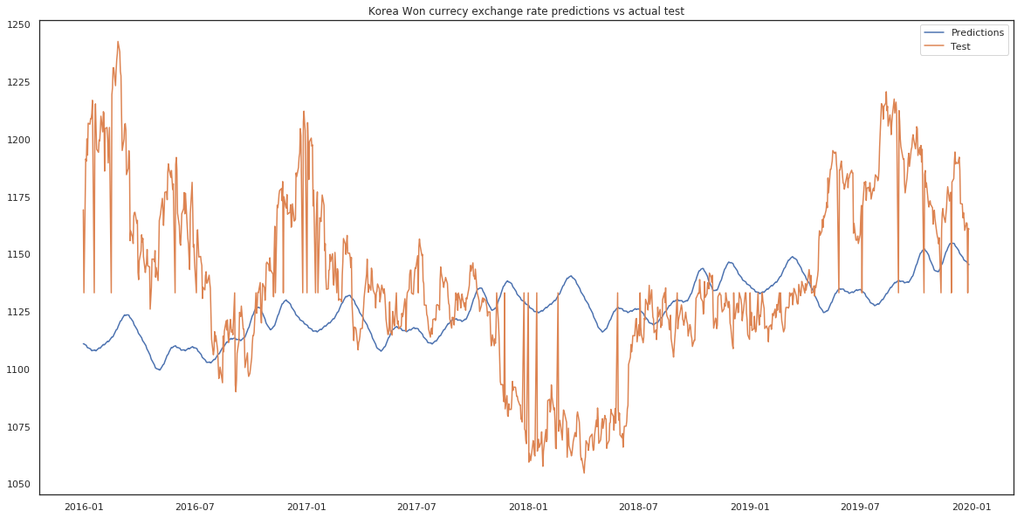

```python
import matplotlib.pyplot as plt
plt.figure(figsize=(20,10))
plt.title("Korea Won currecy exchange rate predictions vs actual test")
predictions, = plt.plot(train_kor_yhat_2["ds"],train_kor_yhat_2["yhat"],label="Predictions")
test, = plt.plot(test_kor_data_2['ds'],test_kor_data_2['y'],label="Test")
plt.legend(loc='upper right')
```

We can see that our predictions were not bad although they did not caputer the sudden drops around 2018-01. I am surpirsed how good facebook's Prophet is at analyzing time series with simple tricks like this!